# [PADK] Regresi Logistik - Regresi Berganda

Angga Fathan Rofiqy

17 November, 2023

Kode di `Hide` dalam *default*, untuk menampilkan kode, klik `Code` .

```r
#                      -=( Install & Load Package Function )=-
install_load <- function (package1, ...)  {

   # convert arguments to vector
   packages <- c(package1, ...)

   # start loop to determine if each package is installed
   for(package in packages){

       # if package is installed locally, load
       if(package %in% rownames(installed.packages()))
          do.call('library', list(package))

       # if package is not installed locally, download, then load
       else {
          install.packages(package)
          do.call("library", list(package))
       }
   }
}

#Path Function
path <- function(){
  gsub  ( "\\\\",  "/",  readClipboard ()  )
}
#Copy path, Panggil function di console
#Copy r path, paste ke var yang diinginkan
```

# 1 Pendahuluan

## 1.1 Kelompok 1

| **Nama** | **NIM** |
| --- | --- |
| Karimatu Ain | G1401211001 |
| Diva Nisfu Mustika | G1401211002 |
| Lutfi Syahreza Lubis | G1401211003 |
| Asfiah Adiba | G1401211004 |
| Angga Fathan Rofiqy | G1401211006 |
| Farhan Abdillah Harahap | G1401211007 |
| Nabil Naufal | G1401211008 |
| Muhammad Rizky Fajar | G1401211009 |
| Mutiara Andhini | G1401211010 |
| Muhammad Nafiz | G1401211011 |
| Syifa Khairunnisa | G1401211012 |
| Reynd Hamonangan Pasaribu | G1401211013 |

## 1.2 Soal

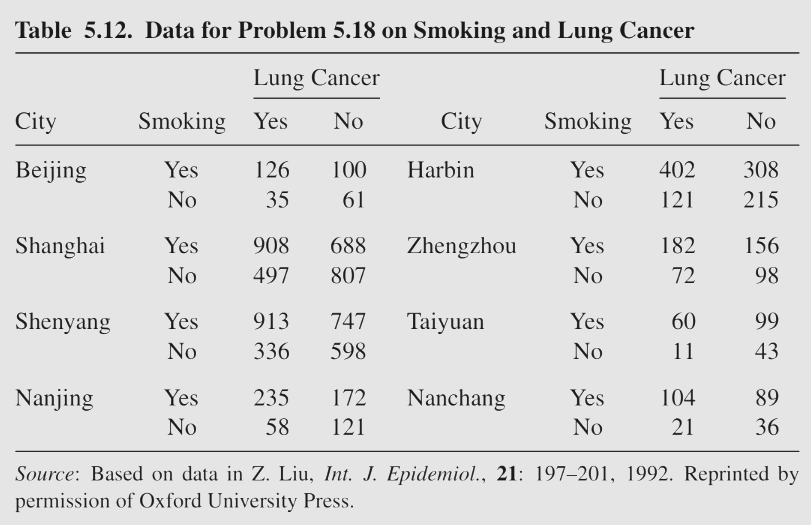

## 1.3 Data Entry

```r
install_load('dplyr', 'DT', 'tidyr', 'stringr')

# Mengubah Tabel Kontingensi ke dalam Data Frame R
data <- data.frame(
  City = rep(c("Beijing", "Shanghai", "Shenyang", "Nanjing", "Harbin", "Zehgzhou", "Taiyuan", "Nanchang"), each = 2),
  Smoking = rep(c("Yes", "No"), times = 8),
  LungCancer_Yes = c(126, 35, 908, 497, 913, 336, 235, 58, 402, 121, 182, 72, 60, 11, 104, 21),
  LungCancer_No = c(100, 61, 688, 807, 747, 598, 172, 121, 308, 215, 156, 98, 99, 43, 89, 36)
)
datatable(data)
```

|  | City | Smoking | LungCancer_Yes | LungCancer_No |
| --- | --- | --- | --- | --- |
| 1 | Beijing | Yes | 126 | 100 |
| 2 | Beijing | No | 35 | 61 |
| 3 | Shanghai | Yes | 908 | 688 |
| 4 | Shanghai | No | 497 | 807 |
| 5 | Shenyang | Yes | 913 | 747 |
| 6 | Shenyang | No | 336 | 598 |
| 7 | Nanjing | Yes | 235 | 172 |
| 8 | Nanjing | No | 58 | 121 |
| 9 | Harbin | Yes | 402 | 308 |
| 10 | Harbin | No | 121 | 215 |

[output cut: 6 more lines]

## 1.4 Transform Data

```r
data2 <- data %>%
  pivot_longer(cols = c("LungCancer_Yes", "LungCancer_No"),
               names_to = "LungCancer", values_to = "Count") %>%
  mutate(LungCancer = ifelse(str_detect(LungCancer, "Yes"), "Yes", "No")) %>%
  uncount(weights = Count) %>%
  select(City, Smoking, LungCancer) %>%
  mutate(
    City = as.factor(City),
    Smoking = as.factor(Smoking),
    LungCancer = as.factor(LungCancer)
  )
datatable(data2)
```

|  | City | Smoking | LungCancer |
| --- | --- | --- | --- |
| 1 | Beijing | Yes | Yes |
| 2 | Beijing | Yes | Yes |
| 3 | Beijing | Yes | Yes |
| 4 | Beijing | Yes | Yes |
| 5 | Beijing | Yes | Yes |
| 6 | Beijing | Yes | Yes |
| 7 | Beijing | Yes | Yes |
| 8 | Beijing | Yes | Yes |
| 9 | Beijing | Yes | Yes |
| 10 | Beijing | Yes | Yes |

[output cut: 8409 more lines]

## 1.5 Data Checking

### 1.5.1 Tipe Data

```r
str(data2)
```

```
## tibble [8,419 × 3] (S3: tbl_df/tbl/data.frame)
##  $ City      : Factor w/ 8 levels "Beijing","Harbin",..: 1 1 1 1 1 1 1 1 1 1 ...
##  $ Smoking   : Factor w/ 2 levels "No","Yes": 2 2 2 2 2 2 2 2 2 2 ...
##  $ LungCancer: Factor w/ 2 levels "No","Yes": 2 2 2 2 2 2 2 2 2 2 ...
```

Agar dapat bisa dianalisis, data harus bertipe `Factor`. Terlihat bahwa tipe data di atas sudah sesuai.

### 1.5.2 Banyaknya data transform

```r
data_restored <- data2 %>%
  group_by(City, Smoking, LungCancer, .drop = TRUE) %>%
  summarize(Count = n(), .groups = 'drop') %>%
  pivot_wider(names_from = LungCancer, values_from = Count) %>%
  ungroup()
datatable(data_restored)
```

|  | City | Smoking | No | Yes |
| --- | --- | --- | --- | --- |
| 1 | Beijing | No | 61 | 35 |
| 2 | Beijing | Yes | 100 | 126 |
| 3 | Harbin | No | 215 | 121 |
| 4 | Harbin | Yes | 308 | 402 |
| 5 | Nanchang | No | 36 | 21 |
| 6 | Nanchang | Yes | 89 | 104 |
| 7 | Nanjing | No | 121 | 58 |
| 8 | Nanjing | Yes | 172 | 235 |
| 9 | Shanghai | No | 807 | 497 |
| 10 | Shanghai | Yes | 688 | 908 |

[output cut: 6 more lines]

Bisa di cek bahwa. Jumlah data yang di transform sudah benar.

# 2 Jawab Soal

## 2.1 No 1.

> Hitunglah **dugaan parameter** regresi logistik berganda untuk **Peubah Smoking**

```r
model <- glm(LungCancer ~ Smoking + City, data = data2, family = binomial)
summary(model)
```

```
##
## Call:
## glm(formula = LungCancer ~ Smoking + City, family = binomial,
##     data = data2)
##
## Deviance Residuals:
##     Min       1Q   Median       3Q      Max
## -1.3001  -1.2637  -0.9444   1.0935   1.7530
##
## Coefficients:
##               Estimate Std. Error z value Pr(>|z|)
## (Intercept)  -0.548682   0.118022  -4.649 3.34e-06 ***
## SmokingYes    0.777062   0.046775  16.613  < 2e-16 ***
## CityHarbin    0.018187   0.129473   0.140    0.888
## CityNanchang -0.054906   0.170996  -0.321    0.748
## CityNanjing   0.005764   0.140911   0.041    0.967
## CityShanghai  0.055618   0.119570   0.465    0.642
## CityShenyang -0.027739   0.120071  -0.231    0.817
## CityTaiyuan  -0.745683   0.185519  -4.019 5.83e-05 ***
## CityZehgzhou  0.028782   0.144755   0.199    0.842
## ---
## Signif. codes:  0 '***' 0.001 '**' 0.01 '*' 0.05 '.' 0.1 ' ' 1
##
## (Dispersion parameter for binomial family taken to be 1)
##
##     Null deviance: 11663  on 8418  degrees of freedom
## Residual deviance: 11358  on 8410  degrees of freedom
## AIC: 11376
##
## Number of Fisher Scoring iterations: 4
```

Sehingga jawaban yang tepat adalah :

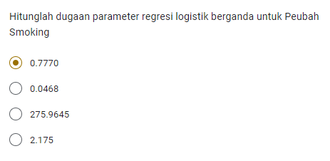

## 2.2 No 2.

> **Nilai odds, p-value, dan Statistik Uji Wald** pada peubah Smoking

```r
summary_model <- summary(model)
rasio.odds <- exp(coef(model)) %>% round(.,3)
p.value <- summary(model)$coefficients[, "Pr(>|z|)"] %>%
  sprintf("%.2e", .)

datatable(data.frame(rasio.odds, p.value))
```

|  | rasio.odds | p.value |
| --- | --- | --- |
| (Intercept) | 0.578 | 3.34e-06 |
| SmokingYes | 2.175 | 5.62e-62 |
| CityHarbin | 1.018 | 8.88e-01 |
| CityNanchang | 0.947 | 7.48e-01 |
| CityNanjing | 1.006 | 9.67e-01 |
| CityShanghai | 1.057 | 6.42e-01 |
| CityShenyang | 0.973 | 8.17e-01 |
| CityTaiyuan | 0.474 | 5.83e-05 |
| CityZehgzhou | 1.029 | 8.42e-01 |

```r
install_load('car')
Anova(model, type="II", test.statistic="Wald")
```

```
## Analysis of Deviance Table (Type II tests)
##
## Response: LungCancer
##         Df   Chisq Pr(>Chisq)
## Smoking  1 275.988  < 2.2e-16 ***
## City     7  28.568  0.0001734 ***
## ---
## Signif. codes:  0 '***' 0.001 '**' 0.01 '*' 0.05 '.' 0.1 ' ' 1
```

Sehingga jawaban yang tepat adalah

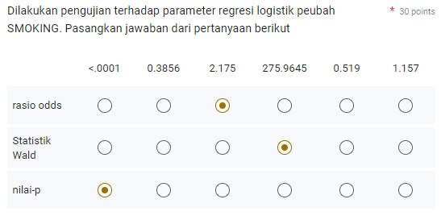

## 2.3 **No 3.**

> **Rasio Odds** Lung Cancer

```r
rasio.odds
```

```
##  (Intercept)   SmokingYes   CityHarbin CityNanchang  CityNanjing CityShanghai
##        0.578        2.175        1.018        0.947        1.006        1.057
## CityShenyang  CityTaiyuan CityZehgzhou
##        0.973        0.474        1.029
```

Sehingga jawaban yang tepat adalah

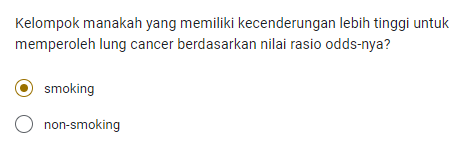

## 2.4 **No 4.**

> **Kota** yang memilikipengaruh yang **signifikan**

```r
model2 <- glm(LungCancer ~ City, data = data2, family = binomial)
summary(model2)
```

```
##
## Call:
## glm(formula = LungCancer ~ City, family = binomial, data = data2)
##
## Deviance Residuals:
##     Min       1Q   Median       3Q      Max
## -1.1774  -1.1512  -0.9005   1.2039   1.4823
##
## Coefficients:
##                Estimate Std. Error z value Pr(>|z|)
## (Intercept)   7.541e-14  1.115e-01   0.000 1.000000
## CityHarbin   -6.900e-14  1.275e-01   0.000 1.000000
## CityNanchang -6.973e-14  1.686e-01   0.000 1.000000
## CityNanjing  -6.508e-14  1.387e-01   0.000 1.000000
## CityShanghai -6.209e-02  1.175e-01  -0.528 0.597167
## CityShenyang -7.405e-02  1.182e-01  -0.627 0.530926
## CityTaiyuan  -6.931e-01  1.832e-01  -3.784 0.000154 ***
## CityZehgzhou -8.823e-14  1.425e-01   0.000 1.000000
## ---
## Signif. codes:  0 '***' 0.001 '**' 0.01 '*' 0.05 '.' 0.1 ' ' 1
##
## (Dispersion parameter for binomial family taken to be 1)
##
##     Null deviance: 11663  on 8418  degrees of freedom
## Residual deviance: 11641  on 8411  degrees of freedom
## AIC: 11657
##
## Number of Fisher Scoring iterations: 4
```

Bisa dilihat pada bagian

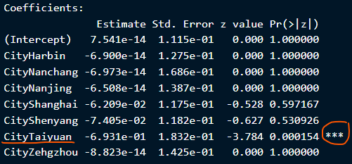

Bahwa **Kota yang memiliki pengaruh yang signifikan** adalah kota **Taiyuan.**

Sehingga jawaban yang tepat adalah

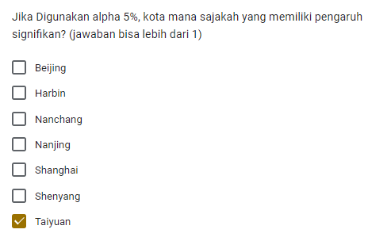

## 2.5 **No 5.**

> Lakukan **Uji kebaikan suai Hosmer** and **Lemeshow** terhadap model yang di tentukan. Tentukan *khi-kuadrat, p-value, keputusan, dan kesimpulan*.

**Hipotesis**

> $H_0$ : Model Cocok

> $H_1$ : Model Tidak cocok

```r
install_load("ResourceSelection")
hoslem.test(model$y, fitted(model))
```

```
##
##  Hosmer and Lemeshow goodness of fit (GOF) test
##
## data:  model$y, fitted(model)
## X-squared = 1.388, df = 8, p-value = 0.9944
```

```r
predicted_probabilities <- predict(model, type = "response")
```

Sehingga jawaban yang tepat adalah

[figure not shown]

## 2.6 **No 6.**

> Jika ingin **diuji** apakah model dengan kovariat city dan smoking **(L1) lebih baik** daripada model dengan hanya intersep saja **(L0)**, maka dilakukan **LR test**.

**Hipotesis**

> $H_0$ : `City` dan `Smoking` tidak berpengaruh terhadap model

> $H_1$ : `City` dan `Smoking` berpengaruh terhadap model

**LR test**

```r
# Model hanya intersep (L0)
model.L0 <- glm(LungCancer ~ 1, data = data2, family = binomial)

# Model dengan City dan Smoking (L1)
model.L1 <- glm(LungCancer ~ City + Smoking, data = data2, family = binomial)

install_load("lmtest")
# Uji LR
lrtest(model.L0, model.L1)
```

```
## Likelihood ratio test
##
## Model 1: LungCancer ~ 1
## Model 2: LungCancer ~ City + Smoking
##   #Df  LogLik Df Chisq Pr(>Chisq)
## 1   1 -5831.7
## 2   9 -5678.8  8 305.7  < 2.2e-16 ***
## ---
## Signif. codes:  0 '***' 0.001 '**' 0.01 '*' 0.05 '.' 0.1 ' ' 1
```

Terlihat bahwa *p-value* bernilai $2.2\times10^{-16}$. Nilainya sangat kecil, sehingga dapat dinyatakan **kurang dari** $0.001$. Sehingga **Tolak** $H_0$, artinya `City` dan `Smoking` **berpengaruh** terhadap model.

**Nilai L0, L1, L0-L1**

```r
# -2log L0
minus2logL0 <- -2 * logLik(model.L0)

# -2log L1
minus2logL1 <- -2 * logLik(model.L1)

# -2log (L0-L1)
minus2logL0.L1 <- minus2logL0 - minus2logL1

log <- data.frame(minus2logL0, minus2logL1, minus2logL0.L1) %>% round(.,2)
colnames(log) <- c("-2log L0", "-2log L1", "-2log (L0-L1)")
datatable(log)
```

|  | -2log L0 | -2log L1 | -2log (L0-L1) |
| --- | --- | --- | --- |
| 1 | 11663.37 | 11357.67 | 305.7 |

Diperoleh nilai $log{(\text{L}_0^{-2})}$ adalah sebesar $11663.37$. Lalu $log{(\text{L}_1^{-2})}$ bernilai $11357.67$. Dan $log{(\text{L}_0-\text{L}_1)^{-2}}$ sebesar $305.7$.

Sehingga jawaban yang tepat adalah

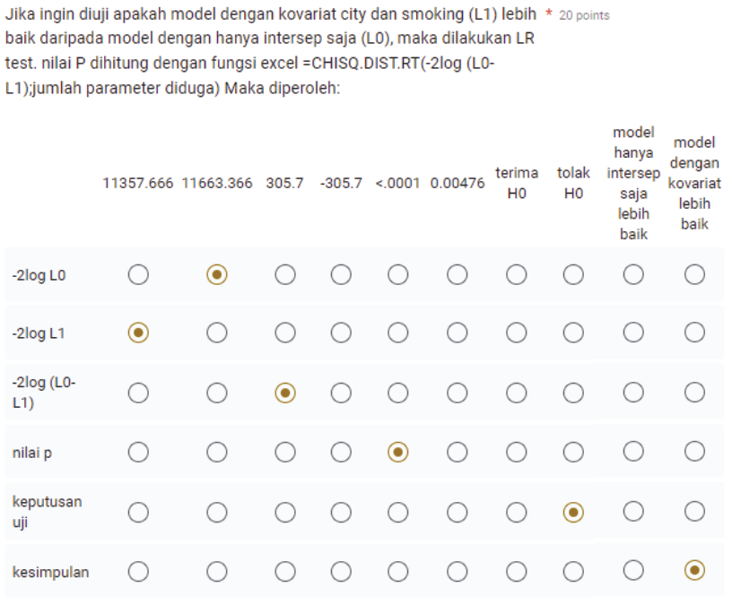

# 3 Hasil software lain

## 3.1 SAS

[File.sas](https://github.com/Zen-Rofiqy/STA1343-PADK/blob/main/Tugas/Tugas%20Kelompok%20Bu%20Pika%201/%5BPADK%5D%20Regresi%20Logistik-Regresi%20Berganda.sas)

### 3.1.1 Code

```
DATA tugas;
INPUT city smoking lungcancer count;
DATALINES;
0 1 1 126
0 1 0 100
0 0 1 35
0 0 0 61
1 1 1 908
1 1 0 688
1 0 1 497
1 0 0 807
2 1 1 913
2 1 0 747
2 0 1 336
2 0 0 598
```

[output cut: 26 more lines]

### 3.1.2 Output

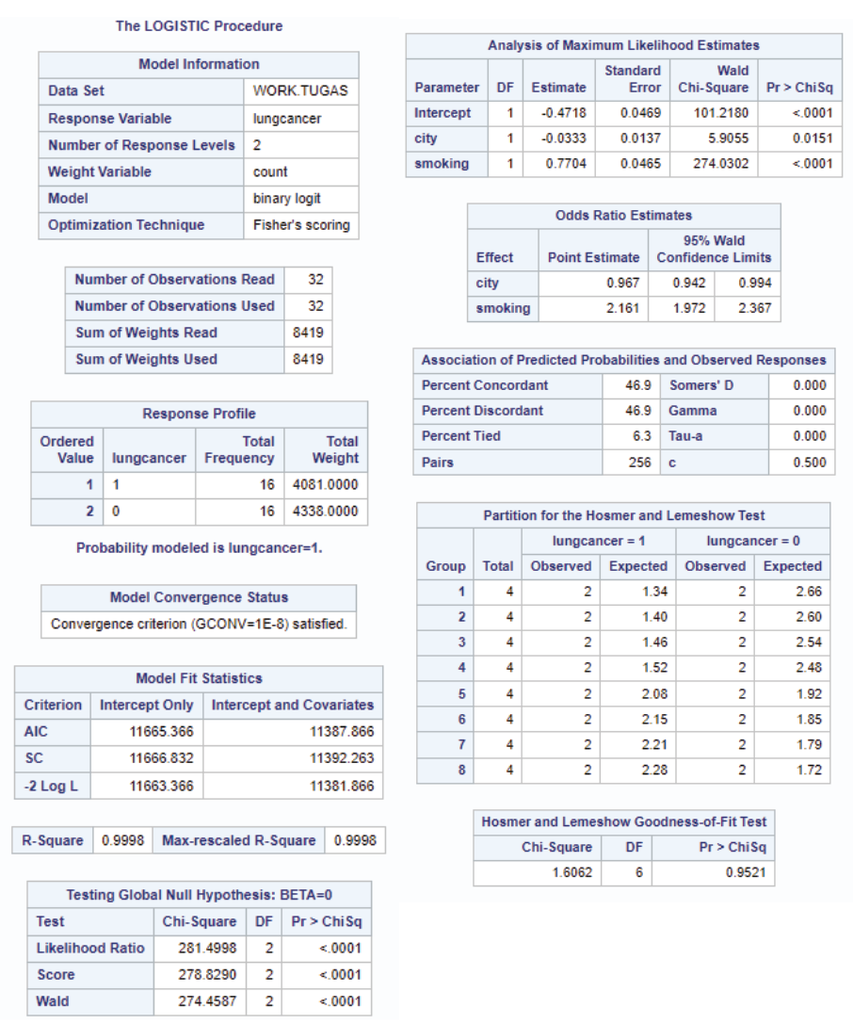

### 3.1.3 Jawab Soal

#### 3.1.3.1 No 1.

> Hitunglah **dugaan parameter** regresi logistik berganda untuk **Peubah Smoking**

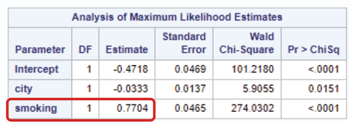

Terlihat bahwa nilai yang diperoleh untuk **dugaan parameter** regresi logistik berganda pada **Peubah Smoking** adalah sebesar $0.7704$.

Sehingga jawaban yang tepat adalah :

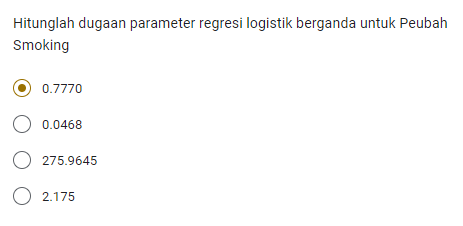

#### 3.1.3.2 No 2.

> **Nilai odds, p-value, dan Statistik Uji Wald** pada peubah `Smoking`

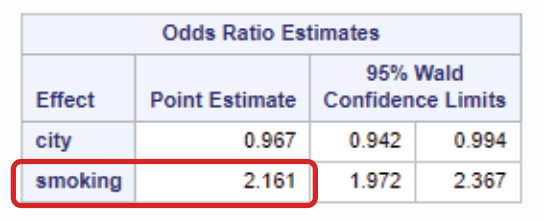

Didapatkan **Nilai odds** pada peubah `Smoking` sebesar $2.161$.

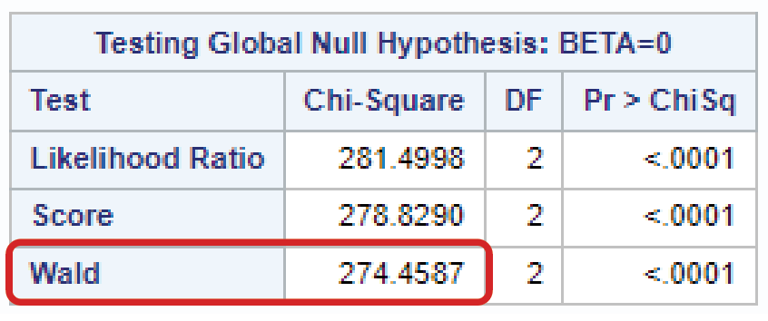

Sehingga jawaban yang tepat adalah

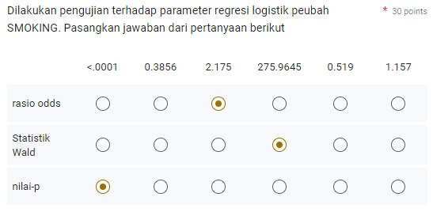

#### 3.1.3.3 No 3.

> **Rasio Odds** Lung Cancer

Sehingga jawaban yang tepat adalah

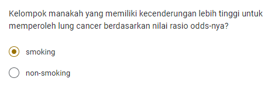

#### 3.1.3.4 No 4.

> **Kota** yang memilikipengaruh yang **signifikan**

Sehingga jawaban yang tepat adalah

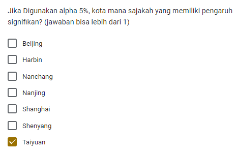

#### 3.1.3.5 No 5.

> Lakukan **Uji kebaikan suai Hosmer** and **Lemeshow** terhadap model yang di tentukan. Tentukan *khi-kuadrat, p-value, keputusan, dan kesimpulan*.

**Hipotesis**

> $H_0$ : Model Cocok

> $H_1$ : Model Tidak cocok

Sehingga jawaban yang tepat adalah

[figure not shown]

#### 3.1.3.6 No 6.

> Jika ingin **diuji** apakah model dengan kovariat city dan smoking **(L1) lebih baik** daripada model dengan hanya intersep saja **(L0)**, maka dilakukan **LR test**.

**Hipotesis**

> $H_0$ : `City` dan `Smoking` tidak berpengaruh terhadap model

> $H_1$ : `City` dan `Smoking` berpengaruh terhadap model

Sehingga jawaban yang tepat adalah

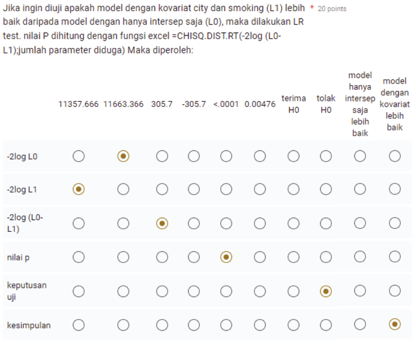

## 3.2 Minitab